# Inferencia en la Distribucion Gaussiana Multivariada

## Paquetes

### *Loading*

Cargamos los paquetes que usaremos en estas ilustraciones.

[output not shown]

[output not shown]

[output not shown]

[output not shown]

[output not shown]

## Parte 1 - Inferencia via MLE

## Intuicion

### Caso Univariado (\(p=1\))

Retomemos el caso univariado de la distribucion gaussiana, con densidad

\[ f(x|\mu,\sigma^2) = (2\pi)^{-1/2} \sigma^{-1} \exp\left\{-(1/2\sigma^2) (x-\mu)^2\right\} \] teniendo para \(x\) soporte en \(\Re\).

**Recordemos:** El espacio parametral para (\(\mu\),\(\sigma^2\)) es \(\Re\) \(\times\) \(\Re_{+}\).

## Visualizacion

### Funcion de verosimilitud

```r
mu_x <- 114.4
sigma2_x <- 5.29

x <- seq(100,130,.1)
y <- dnorm(x,mu_x,sqrt(sigma2_x))

png("density.png", 490, 390)
plot(x,y,type="l",xlab="X",ylab="f(x)",cex=5,lwd=5)

xloc = 114.4
yloc = dnorm(xloc,mu_x,sqrt(sigma2_x))
lines(c(xloc,xloc),c(-1,yloc),cex=5,lwd=5,lty=2)
lines(c(00,xloc),c(yloc,yloc),cex=5,lwd=5,lty=2)

xloc=110
yloc = dnorm(xloc,mu_x,sqrt(sigma2_x))
lines(c(xloc,xloc),c(-1,yloc),cex=5,lwd=5,lty=3)
lines(c(00,xloc),c(yloc,yloc),cex=5,lwd=5,lty=3)
dev.off()
```

## Visualizacion

### Funcion de densidad

En este caso la variabilkidad esta restringida a \(X\) tomando \(\mu\) y \(\sigma\) fijos.

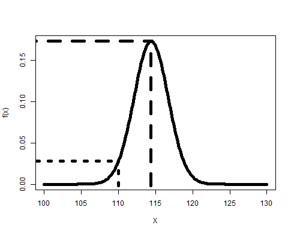

Densidad gaussiana unidimensional

## Visualizacion

### Funcion de verosimilitud para \(\mu\) con base en un dato \(x=112\)

```r
mu = seq(100,124,.01)
x = 112
sigma2 = 5.29
y = dnorm(x,mu,sqrt(sigma2))

png("likelihood.png", 490, 390)
plot(mu,y,type="l",xlab=expression(mu[x]),ylab=expression(paste("L(",mu[x],"|x,",sigma[x]^2,")")),cex=3,lwd=5,main=expression(paste("Verosimilitud para ",mu[x])))
muloc=112
yloc=dnorm(x,muloc,sqrt(sigma2))
lines(c(muloc,muloc),c(-1,yloc),cex=5,lwd=5,lty=2)
lines(c(00,muloc),c(yloc,yloc),cex=5,lwd=5,lty=2)
dev.off()
```

## Visualizacion

### Funcion de verosimilitud para \(mu\) con base en un dato \(x=112\)

En este caso la variabilidad esta referida a \(\mu\) tomando \(x=112\) y \(\sigma\) fijos.

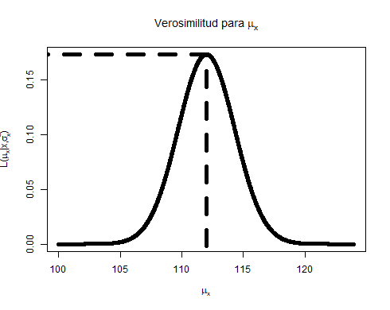

## Visualizacion

### Funcion de verosimilitud para \(\mu\) con base en una muestra

```r
perf = matrix(c(10,12,14,16,12))
iq = c(112,113,115,118,114)

#for the likelihood (without a log)
mu = seq(100,124,.1)
mudim = dim(matrix(mu))[1]
y = mu
sigma2_x = 5.29

for (i in 1:mudim) {
  likelihood = 1
  for (j in 1:5) {
    likelihood=likelihood*dnorm(iq[j],mu[i],sqrt(sigma2_x))
  }
  y[i]=likelihood
}

# Maximum likelihood
maxL = max(y)

# ubicacion
MLEmu = mu[which.max(y)]

png("likelihood_n.png", 490, 390)
plot(mu,y,type="l",xlab=expression(mu[x]),ylab=expression(paste("L(",mu[x],"|x,",sigma[x]^2,")")),lwd=5)
lines(c(MLEmu,MLEmu),c(-1,maxL),lwd=5,lty=2)
lines(c(90,MLEmu),c(maxL,maxL),lwd=5,lty=2)
dev.off()
```

## Visualizacion

### Funcion de verosimilitud para \(\mu\) con base en una muestra

En este caso la variabilidad esta referida a \(\mu\) tomando los datos y \(\sigma\) fijos.

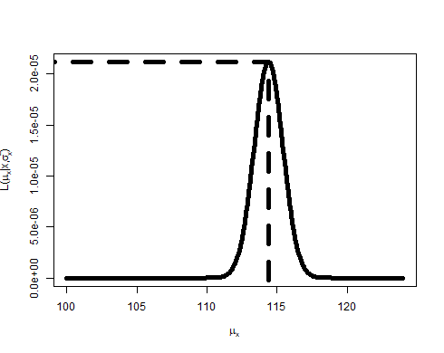

Verosimilitud gaussiana unidimensional

## Visualizacion

### Funcion de log-verosimilitud para \(\mu\) con base en una muestra

```r
mu = seq(100,124,.1)
mudim = dim(matrix(mu))[1]
y = mu

for (i in 1:mudim) {
  likelihood = 0
  for (j in 1:5) {
    likelihood=likelihood+dnorm(iq[j],mu[i],sqrt(sigma2_x),log=TRUE)
  }
  y[i]=likelihood
}
#  Maximo
maxLogL = max(y)

# Ubicacion
MLEmu = mu[which.max(y)]

png("log_likelihood_n.png", 490, 390)
plot(mu,y,type="l",xlab=expression(mu),ylab="logL",lwd=5)
lines(c(MLEmu,MLEmu),c(-125,maxLogL),lwd=5,lty=2)
lines(c(90,MLEmu),c(maxLogL,maxLogL),lwd=5,lty=2)
dev.off()
```

## Visualizacion

### Funcion de verosimilitud para \(\mu\) con base en una muestra

En este caso la variabilidad esta referida a \(\mu\) tomando los datos y \(\sigma\) fijos.

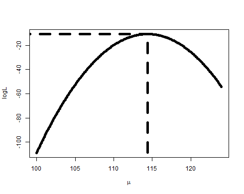

Verosimilitud gaussiana unidimensional

## Visualizacion

### Funcion de verosimilitud conjunta

```r
iq = matrix(c(112,113,115,118,114))
n = dim(matrix(iq))[1]
mu = matrix(seq(114.3,114.5,.01))
nstep = dim(matrix(mu))[1]

sigma = matrix(seq(2.0581,2.0601,.0001))
dim(sigma)
```

```
## [1] 21  1
```

```r
dim(mu)
```

```
## [1] 21  1
```

```r
x=matrix(0,nstep,1)
y=matrix(0,nstep,1)
z=matrix(0,nstep,nstep)

maxval = -999999
maxmu = 0
maxsigma = 0
for (i in 1:nstep){
  for (j in 1:nstep){
    x[i]=mu[i]
    y[j]=sigma[j]^2
    z[i,j]=0

    for (k in 1:n) {
      z[i,j] = z[i,j]+dnorm(iq[k],mu[i],sigma[j],log=TRUE)
    }

    if (z[i,j]>maxval) {
      maxval = z[i,j]
      maxmu=mu[i]
      maxsigma=sigma[j]
    }

  }

}
```

## Visualizacion

### Funcion de verosimilitud conjunta

```r
maxmu
```

```
## [1] 114.4
```

```r
maxsigma
```

```
## [1] 2.0591
```

```r
png("joint_likelihood_n.png", 490, 390)
grid.list=list(x=x,y=y)
mygrid=make.surface.grid(grid.list)
out=list(x=grid.list$x,y=grid.list$y,z=z)
par(mfrow=c(1,2))
plot.surface(out,type="p",xlab="Media",ylab="Varianza",zlab="Log L",main="")
plot.surface(out,type="c",xlab="test",ylab="Slope",zlab="SSE",main="Log Likelihood")
max(z)
```

```
## [1] -10.7061
```

```r
dev.off()
```

## Visualizacion

### Funcion de verosimilitud conjunta para \((\mu,\sigma^2)\)

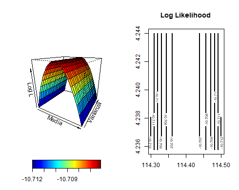

Verosimilitud gaussiana conjunta unidimensional

## Parte 2 - Distribuciones para parametros

## Covarianzas

### Distribucion Wishart

El valor esperado de \(\Sigma\) es \[ \mathbb{E}(\Sigma)=\nu S^{-1}. \]

**Casos particulares:**

## Covarianzas

### Distribucion Wishart

Una propiedad imporante de a distribucion Wishart (y *inverse-Wishart*) es que las distribuciones de sus marginales sobre la diagonal son gamma (o *inverse-gamma*).

En esta seccion visualizaremos las distribuciones marginales de los elementos de una matriz de varianzas y covarianzas con distribucion `inverse-Wishart`.

1. Hiperparametros de la distribucion inverse-Wishart

Primero, definimos los hiper-parametros de la distribucion. En este caso son dos, un parametro escalar para los `grados de libertad` y una matrix simetrica positivo definida, que es el parametro `matriz de escala`.

```r
S <- matrix(c(1,.3,.3,2),2,2)   # matriz de escala
nu  <- 5                          # grados de libertad
```

## Covarianzas

### Distribucion Wishart

1. Distribuciones marginales de las varianzas

Este es un resultados importante. Si \(\Sigma \sim invW(S, \nu)\), entonces \[ \sigma_{ii} \sim invGa(\alpha = \nu/2, \beta = S_{ii}/2), \] donde \(\Sigma=\left(\sigma_{ij}\right)_{i,j=1}^{p}\).

```r
limits <- sapply(diag(S),
                function(x) qinvgamma(c(.01, .99),
                shape = nu/2, scale = x/2))
```

Podemos graficar las distribuciones marginales en la misma escala.

```r
limits <- c(min(limits[1, ]), max(limits[2, ]))
var <- seq(limits[1], limits[2], length = 501)
density <- do.call('c',
       lapply(diag(S),
         function(ss) dinvgamma(var,shape = nu/2,scale = ss/2)))

priordf.var <- data.frame(comp = factor(c(rep('sigma_11', length(var)),
                                          rep('sigma2_22', length(var)))),
                          var = c(var, var),
                          density)
```

Plot prior curves and true value

```r
png("aaa.png", 490, 390)
ggplot(priordf.var, aes(var, density, col = comp)) +
  geom_line() +
  theme_bw()
dev.off()
```

[output not shown]